[figure not shown]

International School of Engineering [www.insofe.edu.in](http://isnofe.edu.in)

# Introduction

Gautham Peddireddy  
20th May 2017

### Tools

- You will be mainly using following Open-Source softwares in the course:
  - R
    - Base R
    - R Studio
    - R Markdown
  - Python
    - Spyder
    - Jupyter Notebook
  - Github

### Python

- History
  - Python was developed by Guido van Rossum, a dutch programmer, in 1989.
  - He is known as 'Benevolent Dictator For Life' (BDFL) in Python community
- Applications
  - Scientific computations
  - Big Data & Analytics
  - Web and GUI Development
  - Many more!

### Python IDEs

- Spyder is one of the popular IDEs which provide running python script through desktop interface
- The Jupyter Notebook provides interactive computing environment that enables users to author documents containing code as well as rich text format

[figure not shown]

[figure not shown]

### Git & GitHub

- Git is a distributed control system (DVCS) for tracking changes in computer files and collabortaing on those files with your team.
- GitHub is hosting service for your repositories which can be version controlled via Git.

[figure not shown]

### About R

- Derived from '**S**' language and developed by **R**os Ihaka and **R**obert Gentleman in 1992
- Free software environment for statistical computing, data analytics and scientific research.
- Advanced capabilities like R-Notebooks, R-Presentation and Web Shiny Apps (This presentation is made in R!)

### R Studio

- Integrated development environment (IDE) for R.
- Available in open source and commercial editions
- Runs on
  - The desktop (Windows, Mac, and Linux) or
  - In a browser connected to RStudio Server or RStudio Server Pro

### Working with R

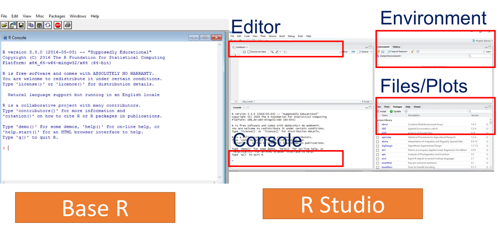

### R Environment

- Environment can be thought as bag of names
- Environment name points to an oject stored elsewhere in memory
- The objects do not live in the environment so multiple names can point to the same object

### Three special Environments

- Global Environment
  - This is the environment in which you normally work.
  - The parent of the global environment is the last package that you attached with library() or require().
- Base environment
  - Is the environment of the base package. Its parent is the empty environment.
- Empty environment
  - Is the ultimate ancestor of all environments, and the only environment without a parent.

### Atomic Objects

- Character
- Numeric (real numbers)
- Integer
- Complex
- Logical (True/False)

### Evaluation and Printing

- The “<-” Or “=” symbols works as the assignment operator.

```r
x <- 5  ## nothing printed
x # Auto printing
```

```
[1] 5
```

```r
print(x) # Explicit printing
```

```
[1] 5
```

```r
x = 6   ## nothing printed
x # Auto printing
```

```
[1] 6
```

```r
print(x) # Explicit printing
```

```
[1] 6
```

- The [1] indicates the x is a vector and 5 is the first element in that vector

### Series

- The “:” operator is used to create integer Sequences

```r
x = 1:20
x
```

```
 [1]  1  2  3  4  5  6  7  8  9 10 11 12 13 14 15 16 17 18 19 20
```

### Vectors

- The most basic object is a vector
  - A vector can only contain objects of the same class with exception of list which can contain objects of several classes
- vectors can be created with 'The vector()' function.

```r
vector(mode='integer',length=6)
```

```
[1] 0 0 0 0 0 0
```

```r
vector(mode='logical',length=6)
```

```
[1] FALSE FALSE FALSE FALSE FALSE FALSE
```

### Creating Vectors

Use `c()` function

```r
x1=c(0.5,0.6)
x2=c(TRUE,FALSE)
x3=c(T,F)
x4=c('alpha','beta','gamma')
x5=9:29
x6=c(1+2i,2+4i)
```

### Matrices

- Matrices are vectors with dimension attributes
- Dimension attribute is itself and integer vector of length 2

```r
v=vector(mode='integer',length=6)
m=matrix(data=v,nrow=2,ncol=3)
m
```

```
     [,1] [,2] [,3]
[1,]    0    0    0
[2,]    0    0    0
```

```r
dim(m)
```

```
[1] 2 3
```

```r
attributes(m)
```

```
$dim
[1] 2 3
```

### Matrices

- Matrices are constructed column-wise.

```r
m <- matrix(1:6, nrow = 2, ncol = 3)
m
```

```
     [,1] [,2] [,3]
[1,]    1    3    5
[2,]    2    4    6
```

### cbind-ing and rbind-ing

- Matrices can be created by column-binding or row-binding with cbind() and rbind().

```r
x <- 1:3
y <- 10:12
cbind(x, y)
```

```
     x  y
[1,] 1 10
[2,] 2 11
[3,] 3 12
```

```r
rbind(x, y)
```

```
  [,1] [,2] [,3]
x    1    2    3
y   10   11   12
```

### Data Frames

- Data frames are used to store tabular data.
  - Unlike matrices, data frames can store different classes of objects in each column; matrices must have every element be the same class.

```r
x <- data.frame(Cid = 1:4, Purchase = c(T, T, F, F))
x
```

```
  Cid Purchase
1   1     TRUE
2   2     TRUE
3   3    FALSE
4   4    FALSE
```

```r
nrow(x)
```

```
[1] 4
```

```r
ncol(x)
```

```
[1] 2
```

### Reading Data

- There are a few principal functions reading data into R.
  - read.table, read.csv, for reading tabular data
  - readLines, for reading lines of a text file
  - source, for reading in R code files (inverse of dump)
  - load, for reading in saved workspaces

### Reading Data

```r
data <- read.csv("data.csv",sep = ",")
data
```

```
  X...Id Temperature
1     s1         3.5
2     s2         2.5
3     s3         2.7
4     s4         2.9
5     s5         3.1
```

```r
dim(data)
```

```
[1] 5 2
```